# Heeren_NUC203_HW4-Copy1

## Homework 4

Big Data

Elizabeth (Libby) Heeren

$~$

#### P1 (35pt): Write a Python code using NumPy, Matplotlib, and Keras to perform image classification for the Fashion_MINIST datset (https://github.com/zalandoresearch/fashionmnist)

$~$

1- (5pt) Load the dataset using tf.keras.datasets.fashion_mnist.load_data() and show the first 12 images of the training dataset in two rows.

```python
import numpy as np
from numpy.random import seed
import tensorflow as tf
from tensorflow import keras
from keras import layers
from keras import models
from matplotlib import pyplot as plt
from keras.utils import to_categorical
from keras.models import load_model

# Set seed for experiment reproducibility
seed = 0
tf.random.set_seed(seed)
np.random.seed(seed)
```

```python
(train_images, train_labels), (test_images, test_labels) = tf.keras.datasets.fashion_mnist.load_data()
```

```
Downloading data from https://storage.googleapis.com/tensorflow/tf-keras-datasets/train-labels-idx1-ubyte.gz
Downloading data from https://storage.googleapis.com/tensorflow/tf-keras-datasets/train-images-idx3-ubyte.gz
Downloading data from https://storage.googleapis.com/tensorflow/tf-keras-datasets/t10k-labels-idx1-ubyte.gz
Downloading data from https://storage.googleapis.com/tensorflow/tf-keras-datasets/t10k-images-idx3-ubyte.gz
```

[figure not shown]

```python
# First 12 images of the training dataset in two rows

for i in range(12):
	# define subplot
	plt.subplot(2, 6, 1+i) # out of 2 rows, 6 columns, have subplot fill position (i+1)
                         # because positions run 1-12 left to right top, then left to right bottom
	# plot raw pixel data
	plt.imshow(train_images[i], cmap=plt.get_cmap('gray'))
# show the figure
plt.show()
```

2- (5pt) Add the “depth” dimension to the training/testing image data using .reshape() and normalize the pixel values of images into [0, 1]. Print out the shapes of training and testing datasets.

```python
# re-shape to be 28*28*1
train_images = train_images.reshape((60000, 28, 28, 1))
test_images = test_images.reshape((10000, 28, 28, 1))

# normalize to a numb between 0 and 1 - 255/255=1 or a number less than 255 divided by 255 is 0.something
test_images = test_images.astype('float32') / 255
train_images = train_images.astype('float32') / 255
```

```python
print(set(test_labels)) # the unique values of the labels

# we need to one hot encode the labels since it's 10-way classification and we need 10,1 dummies in background
train_labels = to_categorical(train_labels)
test_labels = to_categorical(test_labels)
```

```
{0, 1, 2, 3, 4, 5, 6, 7, 8, 9}
```

```python
# Print shapes of train and test sets
print('Train Images Shape = %s, Train Labels Shape = %s' % (train_images.shape, train_labels.shape))
print('Test Images Shape = %s,  Test Labels Shape = %s' % (test_images.shape, test_labels.shape))
```

```
Train Images Shape = (60000, 28, 28, 1), Train Labels Shape = (60000, 10)
Test Images Shape = (10000, 28, 28, 1),  Test Labels Shape = (10000, 10)
```

3- (10pt) Build a CNN model using a stack of Conv2D (128 filters of size (3, 3) with ReLU activation), MaxPooling2D (pool size of (2, 2)), Conv2D (64 filters of size (3, 3 with ReLU activation), MaxPooling2D (pool size of (2, 2)), Dense (128 hidden units with ReLU activation), and output layer. Display the model architecture using .summary().  
$~$ o You need to specify other parameters of the input layer and output layer.

```python
tf.random.set_seed(seed)
np.random.seed(seed)

model = models.Sequential()
# Conv2D (128 filters of size (3, 3) with ReLU activation)
model.add(layers.Conv2D(128, (3, 3), activation='relu', input_shape=(28, 28, 1)))
# MaxPooling2D (pool size of (2, 2))
model.add(layers.MaxPooling2D((2, 2)))
# Conv2D (64 filters of size (3, 3 with ReLU activation)
model.add(layers.Conv2D(64, (3, 3), activation='relu'))
# MaxPooling2D (pool size of (2, 2))
model.add(layers.MaxPooling2D((2, 2)))
# Flatten layer
model.add(layers.Flatten())
# Dense (128 hidden units with ReLU activation)
model.add(layers.Dense(128, activation='relu'))
# and output layer
model.add(layers.Dense(10, activation='softmax')) # we have 10 unique classes
```

```python
model.summary()
```

```
Model: "sequential"
_________________________________________________________________
Layer (type)                 Output Shape              Param #
=================================================================
conv2d (Conv2D)              (None, 26, 26, 128)       1280
_________________________________________________________________
max_pooling2d (MaxPooling2D) (None, 13, 13, 128)       0
_________________________________________________________________
conv2d_1 (Conv2D)            (None, 11, 11, 64)        73792
_________________________________________________________________
max_pooling2d_1 (MaxPooling2 (None, 5, 5, 64)          0
_________________________________________________________________
flatten (Flatten)            (None, 1600)              0
_________________________________________________________________
dense (Dense)                (None, 128)               204928
_________________________________________________________________
dense_1 (Dense)              (None, 10)                1290
=================================================================
Total params: 281,290
Trainable params: 281,290
Non-trainable params: 0
_________________________________________________________________
```

4- (10pt) Compile and train the model for 10 epochs and batch size of 32. Set verbose = 0 during the training to compress the training progress. Draw the plot of the training accuracy w.r.t. the epoch number.  
$~$ o You need to specify the right optimizer, loss function, and metrics for this task.

```python
tf.random.set_seed(seed)
np.random.seed(seed)

model.compile(optimizer='rmsprop',  # do we need to shorten the learning rate?
              loss='categorical_crossentropy', # use sparse_categorical_crossentropy if label has not been one hot encoded
              metrics=['accuracy'])

# change to GPU before running this
m = model.fit(train_images, train_labels, epochs=10, batch_size=32, verbose = 0)
```

```python
m.history.keys()
```

```
dict_keys(['loss', 'accuracy'])
```

```python
acc = m.history['accuracy']
```

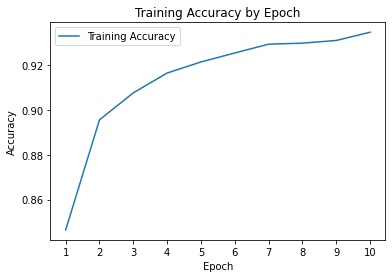

```python
# line points
x = range(1, 11)
y = acc
# plotting the linepoints
plt.plot(x, y, label = "Training Accuracy")
# make sure there are ticks for each epoch for easy reading
plt.xticks(range(1,11))
plt.xlabel('Epoch')
# Set the y axis label of the current axis.
plt.ylabel('Accuracy')
# Set a title of the current axes.
plt.title('Training Accuracy by Epoch')
# show a legend on the plot
plt.legend()
# Display a figure.
plt.show()
```

5- (5pt) Test your trained model on the testing dataset and observe the loss and accuracy.

```python
test_loss, test_acc = model.evaluate(test_images, test_labels)
```

```python
test_acc
```

```
0.9070000052452087
```

```python
test_loss
```

```
0.33091437816619873
```

#### P2 (65pt): Write a Python code using NumPy, Matploblib and Keras to perform image classification using pre-trained model for the CIFAR-10 dataset

(https://www.cs.toronto.edu/~kriz/cifar.html).  
$~$

1- (5pt) Load the dataset using tf.keras.datasets.cifar10.load_data() and show the first 20 images of the training dataset in two rows.  
$~$ o You will obtain the pair of feature matrix and label vector for the training dataset and the pair of feature matrix and label vector for the testing dataset at the end of this step.

```python
(train_images, train_labels), (test_images, test_labels) = tf.keras.datasets.cifar10.load_data()
```

```
Downloading data from https://www.cs.toronto.edu/~kriz/cifar-10-python.tar.gz
```

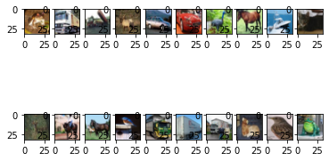

```python
# First 20 images of the training dataset in two rows

for i in range(20):

	# define subplot
  plt.subplot(2, 10, 1+i) # out of 2 rows, 10 columns, have subplot fill position (i+1)
                         # because positions run 1-20 left to right top, then left to right bottom
	# plot raw pixel data
  plt.imshow(train_images[i])

# show the figure
plt.show()
```

2- (5 pt) Reshape the label vectors in both the training and testing datasets to 1D, and compare them with 5 to print out the indices of images that have class labels < 5 and class labels >= 5, respectively, in the training and testing datasets.  
$~$ o You will obtain four index arrays of Boolean values at the end of this step (<5 and >= 5 for training dataset and <5 and >=5 for testing dataset)

```python
train_labels.shape # before re-shape
```

```
(50000, 1)
```

```python
test_labels.shape # before re-shape
```

```
(10000, 1)
```

```python
# re-shape to be 1D
train_labels = train_labels.reshape((50000,))
test_labels = test_labels.reshape((10000,))
```

```python
print(train_labels.shape) # after re=shaping
print(test_labels.shape)
```

```
(50000,)
(10000,)
```

```python
# create logical vectors
train_lessThan5 = train_labels < 5
train_5orMore = train_labels >= 5

test_lessThan5 = test_labels < 5
test_5orMore = test_labels >= 5
```

```python
# Here is what these boolean vectors look like
train_lessThan5[:10]
```

```
array([False, False, False,  True,  True,  True,  True, False, False,
        True])
```

3- (5 pt) Use the index arrays obtained in the previous step to split the training/testing dataset into two subsets (each consisting of a feature matrix and a label vector): one with class labels < 5 and one with class labels >= 5. Print out the shapes of the resulting subsets for both training and testing datasets.  
$~$ o You will obtain four subsets at the end of this step: one pair of training and testing subsets of images with class labels < 5 and another pair of training and testing subsets of images with class labels >= 5.

```python
# Create subsets of images
train_images_lessThan5 = train_images[train_lessThan5 == True]
train_images_5orMore = train_images[train_5orMore == True]

test_images_lessThan5 = test_images[test_lessThan5 == True]
test_images_5orMore = test_images[test_5orMore == True]
```

```python
# Print shapes of image subsets
print("Training set <5 shape: ", train_images_lessThan5.shape)
print("Training set >=5 shape: ", train_images_5orMore.shape)

print("Testing set <5 shape: ", test_images_lessThan5.shape)
print("Testing set >=5 shape: ", test_images_5orMore.shape)
```

```
Training set <5 shape:  (25000, 32, 32, 3)
Training set >=5 shape:  (25000, 32, 32, 3)
Testing set <5 shape:  (5000, 32, 32, 3)
Testing set >=5 shape:  (5000, 32, 32, 3)
```

4- (5pt) Subtract 5 from the label vectors of the pair of training and testing subsets with class labels >= 5 so that 0 represents the first label class in this pair of subsets. Use to_categorical() to transform all labels into their one-hot encoding forms, and normalize the pixel values of all images into [0, 1].

```python
# Create Label subsets
train_labels_lessThan5 = train_labels[train_lessThan5 == True]
train_labels_5orMore = train_labels[train_5orMore == True]

test_labels_lessThan5 = test_labels[test_lessThan5 == True]
test_labels_5orMore = test_labels[test_5orMore == True]
```

```python
# these 5-9 labels need to be 0-4
set(train_labels_5orMore)
```

```
{5, 6, 7, 8, 9}
```

```python
# lower all labels in this subset by 5
train_labels_5orMore -= 5
test_labels_5orMore -= 5
```

```python
# zero is now the first label in the set of 4-9 labels
set(train_labels_5orMore)
```

```
{0, 1, 2, 3, 4}
```

```python
# we need to one hot encode the labels
train_labels_5orMore = to_categorical(train_labels_5orMore)
test_labels_5orMore = to_categorical(test_labels_5orMore)

train_labels_lessThan5 = to_categorical(train_labels_lessThan5)
test_labels_lessThan5 = to_categorical(test_labels_lessThan5)
```

```python
# non-normalized RGB values
train_images_lessThan5[0,0,0]
```

```
array([28, 25, 10], dtype=uint8)
```

```python
# normalize RGB values to a numb between 0 and 1
train_images_lessThan5 = train_images_lessThan5.astype('float32') / 255
train_images_5orMore = train_images_5orMore.astype('float32') / 255

test_images_lessThan5 = test_images_lessThan5.astype('float32') / 255
test_images_5orMore = test_images_5orMore.astype('float32') / 255
```

```python
# normalized RGB values
train_images_lessThan5[0,0,0]
```

```
array([0.10980392, 0.09803922, 0.03921569], dtype=float32)
```

5- (5pt) Build a CNN model_1 using a stack of Conv2D (64 filters of size (3, 3) with ReLU activation), Conv2D (64 filters of size (3, 3) with ReLU activation), MaxPooling2D (pool size of (2, 2)), Dense (128 hidden units with ReLU activation), and output layer. Display the model architecture using .summary() .  
$~$ o You need to specify the correct hyperparameters of the input layer and output layer.

```python
tf.random.set_seed(seed)
np.random.seed(seed)

model = models.Sequential()
# Conv2D (64 filters of size (3, 3) with ReLU activation)
 # model.add(layers.Conv2D(64, (3, 3), activation='relu', input_shape=(32, 32, 3), name = 'layer1'))
layer1 = layers.Conv2D(64, (3, 3), activation='relu', input_shape=(32, 32, 3), name = 'layer1')
model.add(layer1)
# Conv2D (64 filters of size (3, 3) with ReLU activation)
layer2 = layers.Conv2D(64, (3, 3), activation='relu', name = 'layer2')
model.add(layer2)
# MaxPooling2D (pool size of (2, 2))
model.add(layers.MaxPooling2D((2, 2)))
# Flatten layer
model.add(layers.Flatten())
# Dense (128 hidden units with ReLU activation)
dense1 = layers.Dense(128, activation='relu', name = 'dense1')
model.add(dense1)
# and output layer
dense2 = layers.Dense(5, activation='softmax', name = 'dense2')
model.add(dense2) # we have 5 unique classes per subset
```

```python
model.summary()
```

```
Model: "sequential_1"
_________________________________________________________________
Layer (type)                 Output Shape              Param #
=================================================================
layer1 (Conv2D)              (None, 30, 30, 64)        1792
_________________________________________________________________
layer2 (Conv2D)              (None, 28, 28, 64)        36928
_________________________________________________________________
max_pooling2d_2 (MaxPooling2 (None, 14, 14, 64)        0
_________________________________________________________________
flatten_1 (Flatten)          (None, 12544)             0
_________________________________________________________________
dense1 (Dense)               (None, 128)               1605760
_________________________________________________________________
dense2 (Dense)               (None, 5)                 645
=================================================================
Total params: 1,645,125
Trainable params: 1,645,125
Non-trainable params: 0
_________________________________________________________________
```

6- (10pt) Compile and train the model on the subset of training images with class labels < 5 for 20 epochs and batch size of 128. Set verbose = 0 during the training to compress the results. Draw the plot of the training accuracy w.r.t. the epoch number.  
$~$ o You need to specify the correct optimizer, loss function, and metrics for this task.

```python
tf.random.set_seed(seed)
np.random.seed(seed)

model.compile(optimizer='rmsprop',
              loss='categorical_crossentropy',
              metrics=['accuracy'])

# change to GPU before running this
m = model.fit(train_images_lessThan5, train_labels_lessThan5, epochs=20, batch_size=128, verbose = 0)
```

```python
m.history.keys()
```

```
dict_keys(['loss', 'accuracy'])
```

```python
acc = m.history['accuracy']
```

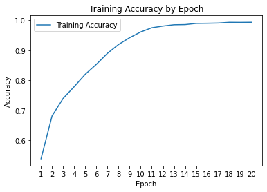

```python
# line points
x = range(1, 21)
y = acc
# plotting the linepoints
plt.plot(x, y, label = "Training Accuracy")
# make sure there are ticks for each epoch for easy reading
plt.xticks(range(1,21))
plt.xlabel('Epoch')
# Set the y axis label of the current axis.
plt.ylabel('Accuracy')
# Set a title of the current axes.
plt.title('Training Accuracy by Epoch')
# show a legend on the plot
plt.legend()
# Display a figure.
plt.show()
```

7- (5pt) Test your trained model_1 on the subset of testing images with class labels <5 and observe the loss and accuracy.

```python
tf.random.set_seed(seed)
np.random.seed(seed)

test_loss, test_acc = model.evaluate(test_images_lessThan5, test_labels_lessThan5)
```

```python
test_acc
```

```
0.7702000141143799
```

```python
test_loss
```

```
1.6754162311553955
```

8- (10pt) Rebuild a new CNN model_2 by reusing the pre-trained convolutional base layers of model_1 (i.e., all layers before applying flatten()) and stacking up new dense and output layers with the same architecture as those of model_1. Display the model architecture using .summary().  
$~$ o You need to freeze the pre-trained convolutional base layers of model_1 so that the model parameters will not be changed during the training of model_2.

```python
# view number of trainable weights in base model
len(model.trainable_weights)
```

```
8
```

```python
# set the top layers to not trainable, bottom 2 dense layers to trainable
model.trainable = True

set_trainable = False
for layer in model.layers:
    if layer.name == 'dense1':
        set_trainable = True
    if set_trainable:
        layer.trainable = True
    else:
        layer.trainable = False
```

```python
# view number of trainable weights in base model after setting half to false
len(model.trainable_weights)
```

```
4
```

```python
# build model2 reusing the prev model layers
tf.random.set_seed(seed)
np.random.seed(seed)

model2 = models.Sequential()
# Conv2D (64 filters of size (3, 3) with ReLU activation)
model2.add(layer1)
# Conv2D (64 filters of size (3, 3) with ReLU activation)
model2.add(layer2)
# MaxPooling2D (pool size of (2, 2))
model2.add(layers.MaxPooling2D((2, 2)))
# Flatten layer
model2.add(layers.Flatten())
# Dense (128 hidden units with ReLU activation)
model2.add(dense1)
# and output layer
model2.add(dense2) # we have 5 unique classes per subset
```

```python
# make sure model2 inherited the same number of trainable layers
len(model2.trainable_weights)
```

```
4
```

```python
model2.summary()
```

```
Model: "sequential_2"
_________________________________________________________________
Layer (type)                 Output Shape              Param #
=================================================================
layer1 (Conv2D)              (None, 30, 30, 64)        1792
_________________________________________________________________
layer2 (Conv2D)              (None, 28, 28, 64)        36928
_________________________________________________________________
max_pooling2d_3 (MaxPooling2 (None, 14, 14, 64)        0
_________________________________________________________________
flatten_2 (Flatten)          (None, 12544)             0
_________________________________________________________________
dense1 (Dense)               (None, 128)               1605760
_________________________________________________________________
dense2 (Dense)               (None, 5)                 645
=================================================================
Total params: 1,645,125
Trainable params: 1,606,405
Non-trainable params: 38,720
_________________________________________________________________
```

9- (10pt) Compile model_2, and train it on the subset of training images with class labels >=5 for 20 epochs and batch size of 128. Draw the plot of the training accuracy w.r.t. the epoch number.

```python
tf.random.set_seed(seed)
np.random.seed(seed)

model2.compile(optimizer='rmsprop',
              loss='categorical_crossentropy',
              metrics=['accuracy'])

# change to GPU before running this
m2 = model2.fit(train_images_5orMore, train_labels_5orMore, epochs=20, batch_size=128, verbose = 0)
```

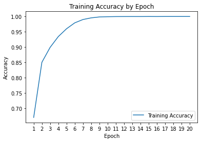

```python
acc = m2.history['accuracy']

# line points
x = range(1, 21)
y = acc
# plotting the linepoints
plt.plot(x, y, label = "Training Accuracy")
# make sure there are ticks for each epoch for easy reading
plt.xticks(range(1,21))
plt.xlabel('Epoch')
# Set the y axis label of the current axis.
plt.ylabel('Accuracy')
# Set a title of the current axes.
plt.title('Training Accuracy by Epoch')
# show a legend on the plot
plt.legend()
# Display a figure.
plt.show()
```

10- (5pt) Test your trained model_2 on the subset of testing images with class labels >=5 and observe the loss and accuracy.

```python
test_loss, test_acc = model2.evaluate(test_images_5orMore, test_labels_5orMore)
```

```python
print(test_acc)
```

```
0.8601999878883362
```

```python
print(test_loss)
```

```
1.3352247476577759
```